# Swiss electricty exports forecasts

Group 1: Samy Maurer, Alexander Liden, Tiffany Davies, Manon Verjus

23/05/2023

First of all let us import the data :

```r
#import data
library(readxl)
library(feasts)
library(ggseas)
library(tsibble)
library(feasts)
library(forecast)
library(fabletools)
library(ggplot2)
library(fable)
library(patchwork)

Electricityraw <- read_excel("Electricity export Switzerland-3.xlsx")
```

# Data cleaning and Wrangling

We started our project by importing the data set and doing some basic modification of the raw data in order to be a bit more readable data set.

```r
# Rename the columns
colnames(Electricityraw) <- c("Date", "Germany", "France", "Austria", "Liechtenstein", "Italy", "Total.Export")
# Remove the first 4 rows
Electricity <- Electricityraw[-c(1:4), ]
# Change Oktober for October
Electricity$Date <- gsub("Oktober", "October", Electricity$Date)
# Convert the date column to a date object
Electricity$Date <- as.Date(paste0("01 ", Electricity$Date), format = "%d %B %Y")
```

The columns were in a character form, so we trandormed them in a numeric format since they represent continuous values.

```r
# Convert the electricity export columns to numeric
Electricity$Germany <- as.numeric(Electricity$Germany)
Electricity$France <- as.numeric(Electricity$France)
Electricity$Austria <- as.numeric(Electricity$Austria)
Electricity$Liechtenstein <- as.numeric(Electricity$Liechtenstein)
Electricity$Italy <- as.numeric(Electricity$Italy)
Electricity$Total.Export <- as.numeric(Electricity$Total.Export)
```

In order to control that our data set is full, we print NA values. As we have 0 NA values for all the columns, we should not have any missing values.

```r
# Check if there are any missing values in the dataset
missing_values <- is.na(Electricity)

# Check if any columns contain missing values
missing_values_per_column <- colSums(missing_values)
print(missing_values_per_column)
```

```
         Date       Germany        France       Austria Liechtenstein         Italy  Total.Export
            0             0             0             0             0             0             0
```

# Vizualisation

## Time series

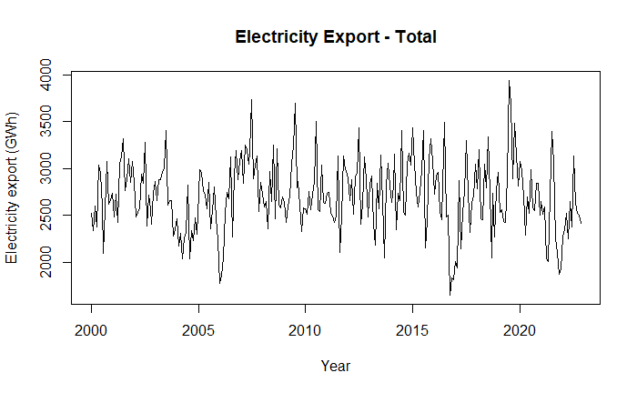

```r
# Create a time series object for the Total.Export data
ts_data <- ts(Electricity$Total.Export, start = c(2000, 1), frequency = 12)
# Create a time series object for the Germany data
ts_germany <- ts(Electricity$Germany, start = c(2000, 1), frequency = 12)
# Create a time series object for the France data
ts_france <- ts(Electricity$France, start = c(2000, 1), frequency = 12)
# Create a time series object for the Italy data
ts_italy <- ts(Electricity$Italy, start = c(2000, 1), frequency = 12)
# Create a time series object for the Austria data
ts_austria <- ts(Electricity$Austria, start = c(2000, 1), frequency = 12)
# Create a time series object for the Liechtenstein data
ts_liechtenstein <- ts(Electricity$Liechtenstein, start = c(2000, 1), frequency = 12)
# Plot the Total.Export time series
plot(ts_data, xlab = "Year", ylab = "Electricity export (GWh)", main = "Electricity Export - Total")
```

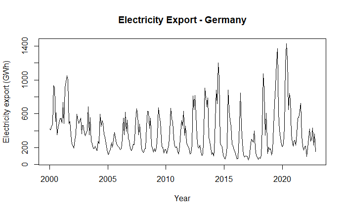

```r
# Plot the Germany time series
plot(ts_germany, xlab = "Year", ylab = "Electricity export (GWh)", main = "Electricity Export - Germany")
```

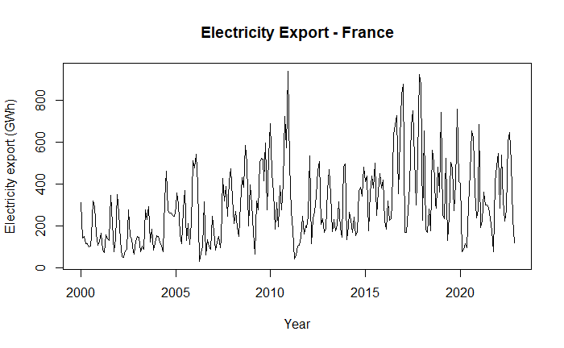

```r
# Plot the France time series
plot(ts_france, xlab = "Year", ylab = "Electricity export (GWh)", main = "Electricity Export - France")
```

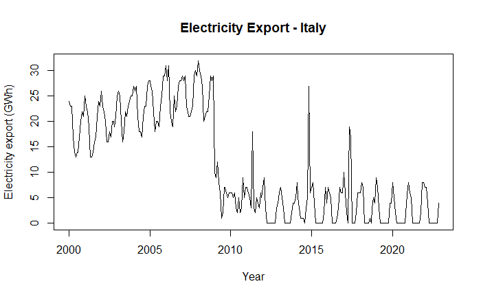

```r
# Plot the Italy time series
plot(ts_italy, xlab = "Year", ylab = "Electricity export (GWh)", main = "Electricity Export - Italy")
```

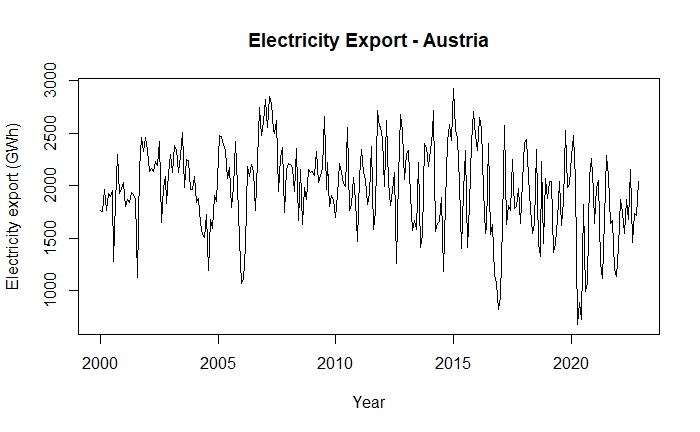

```r
# Plot the Austria time series
plot(ts_austria, xlab = "Year", ylab = "Electricity export (GWh)", main = "Electricity Export - Austria")
```

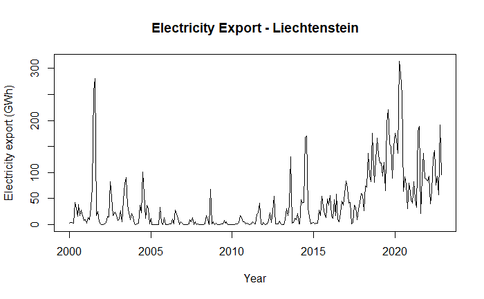

```r
# Plot the Liechtenstein time series
plot(ts_liechtenstein, xlab = "Year", ylab = "Electricity export (GWh)", main = "Electricity Export - Liechtenstein")
```

## STL Decomposition

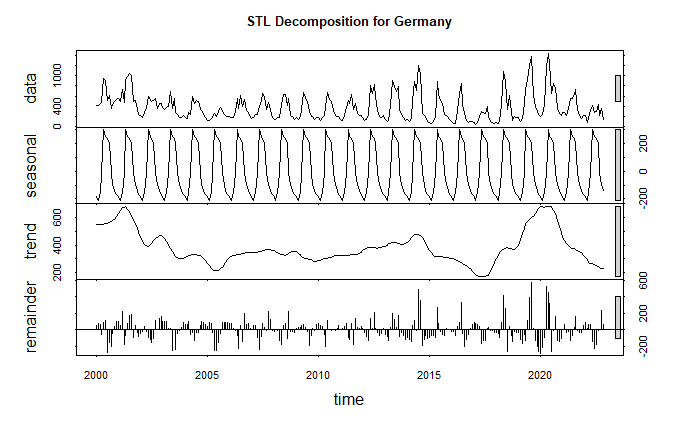

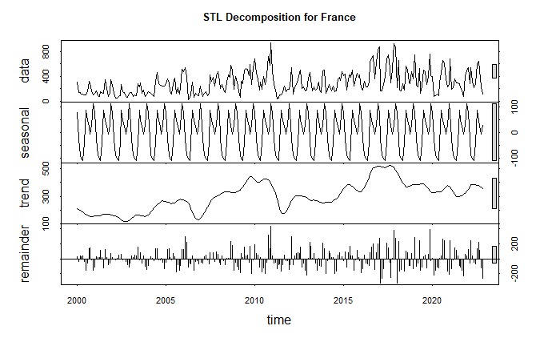

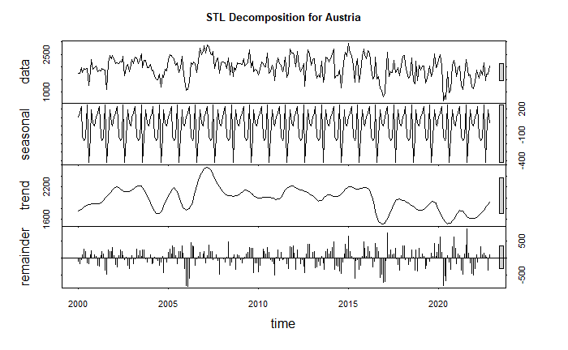

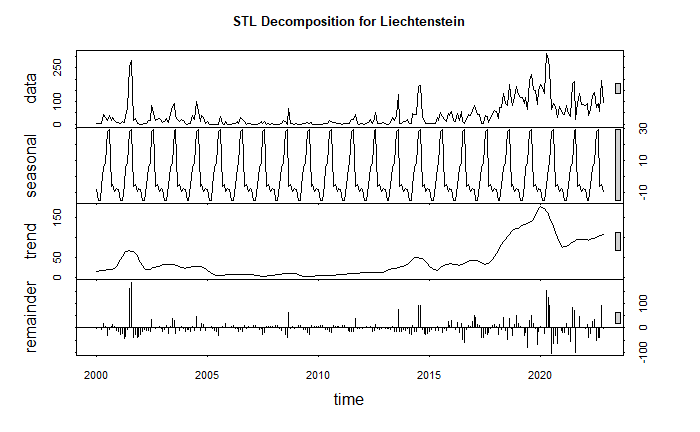

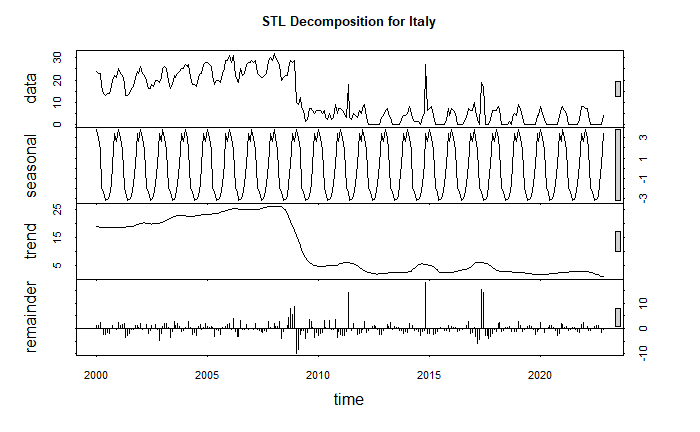

```r
# Define the countries vector
countries <- c("Germany", "France", "Austria", "Liechtenstein", "Italy", "Total.Export")

# Function to create and plot seasonal decomposition for a given country
plot_stl_decomposition <- function(data, country) {
  # Create a time series object
  country_ts <- ts(data[[country]], start = c(2000, 1), frequency = 12)

  # Perform STL decomposition
  country_stl <- stl(country_ts, s.window = "periodic")

  # Plot the seasonal decomposition
  plot(country_stl, main = paste("STL Decomposition for", country))
}

# Use the function to create and display STL decomposition plots for each country
for (country in countries) {
  plot_stl_decomposition(Electricity, country)
}
```

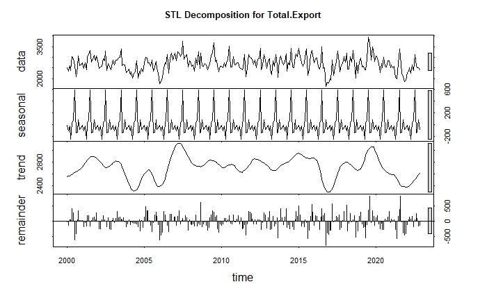

```r
NA
```

Based on the time series results, we plotted a STL decomposition to see if there is some seasonality or not. For Italy, we observe a clear seasonality with raises in Winter and drops in Summer. As for the trend, from 2000 to 2008, we observe a small increase followed by huge drop until 2010. Since 2010, the trend is constant. For Lichtenstein, we identify seasonality with drops every beginning of the years while raising for the Summer. The trend shows constant value until 2017 where there is a huge raise until 2020. This raise is followed by a drop until 2021 and then a small increase. We find out remainders for some countries. It is especially the case for Germany, France and Austria. The remainders could be random noises or it could be explained by irregular effects, model misspecification that does not capture the patterns or nonlinear relationship.

```r
# Convert the time series objects to tsibble objects
ts_data_tsibble <- ts_data %>% as_tsibble(index = index(ts_data))
ts_germany_tsibble <- ts_germany %>% as_tsibble(index = index(ts_germany))
ts_france_tsibble <- ts_france %>% as_tsibble(index = index(ts_france))
ts_italy_tsibble <- ts_italy %>% as_tsibble(index = index(ts_italy))
ts_austria_tsibble <- ts_austria %>% as_tsibble(index = index(ts_austria))
ts_liechtenstein_tsibble <- ts_liechtenstein %>% as_tsibble(index = index(ts_liechtenstein))

# Create seasonal subseries plots for each country using tsibble objects
germany_plot <- gg_subseries(ts_germany_tsibble) +
  ggtitle("Seasonal Subseries Plot for Germany") +
  xlab("Month") + ylab("Electricity Export (GWh)")
```

```
Plot variable not specified, automatically selected `y = value`
```

```r
france_plot <- gg_subseries(ts_france_tsibble) +
  ggtitle("Seasonal Subseries Plot for France") +
  xlab("Month") + ylab("Electricity Export (GWh)")
```

```
Plot variable not specified, automatically selected `y = value`
```

```r
austria_plot <- gg_subseries(ts_austria_tsibble) +
  ggtitle("Seasonal Subseries Plot for Austria") +
  xlab("Month") + ylab("Electricity Export (GWh)")
```

```
Plot variable not specified, automatically selected `y = value`
```

```r
liechtenstein_plot <- gg_subseries(ts_liechtenstein_tsibble) +
  ggtitle("Seasonal Subseries Plot for Liechtenstein") +
  xlab("Month") + ylab("Electricity Export (GWh)")
```

```
Plot variable not specified, automatically selected `y = value`
```

```r
italy_plot <- gg_subseries(ts_italy_tsibble) +
  ggtitle("Seasonal Subseries Plot for Italy") +
  xlab("Month") + ylab("Electricity Export (GWh)")
```

```
Plot variable not specified, automatically selected `y = value`
```

```r
total_export_plot <- gg_subseries(ts_data_tsibble) +
  ggtitle("Seasonal Subseries Plot for Total.Export") +
  xlab("Month") + ylab("Electricity Export (GWh)")
```

```
Plot variable not specified, automatically selected `y = value`
```

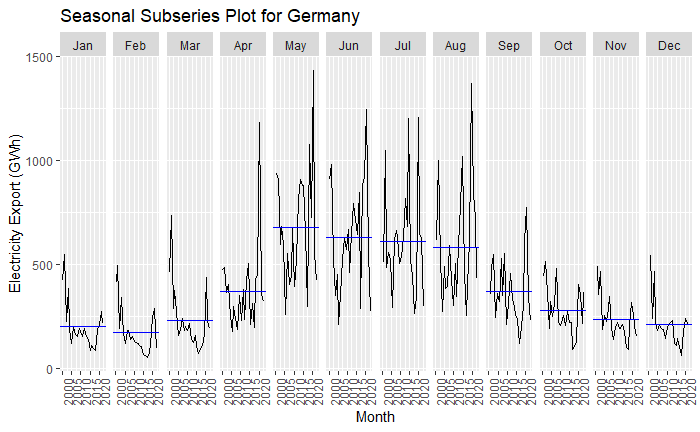

```r
# Display the plots
print(germany_plot)
```

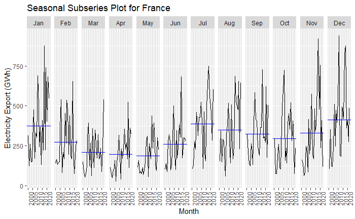

```r
print(france_plot)
```

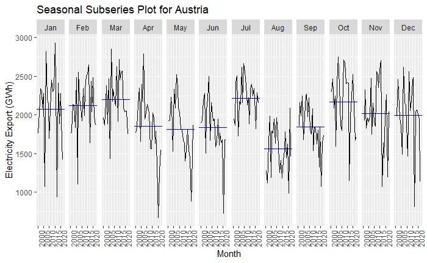

```r
print(austria_plot)
```

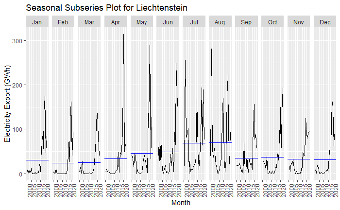

```r
print(liechtenstein_plot)
```

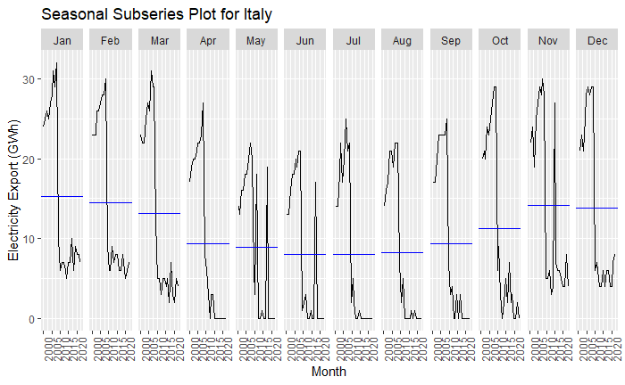

```r
print(italy_plot)
```

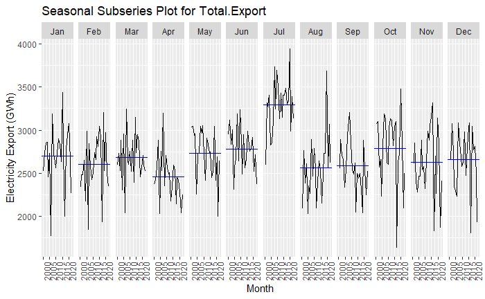

```r
print(total_export_plot)
```

# Modeling

Lets display some of the methods in order to forecast

## ETS model

```r
fit_and_forecast_ets <- function(ts_data, country) {
  # Fit the ETS model with ZZZ (chooses automatically the best)
  ets_model <- ets(ts_data, "ZZZ")

  # Print the chosen model
  cat("Chosen ETS model for", country, ":", ets_model$components, "\n")

  # Generate a forecast
  ets_forecast <- forecast(ets_model, h = 12) # Forecast 12 months ahead

  # Plot the forecast
  plot(ets_forecast, main = paste("ETS Forecast for", country))
}
```

## ARIMA model

```r
# Load the forecast package
library(forecast)

# Function to fit and forecast ARIMA model
fit_and_forecast_arima <- function(ts_data, country) {
  # Fit the ARIMA model
  arima_model <- auto.arima(ts_data, seasonal = FALSE)

  # Generate a forecast
  arima_forecast <- forecast(arima_model, h = 12) # Forecast 12 months ahead

  # Plot the forecast
  plot(arima_forecast, main = paste("ARIMA Forecast for", country))
}
```

## SARIMA (ARIMA with seasonality)

```r
# Load the forecast package
library(forecast)

# Function to fit and forecast ARIMA model
fit_and_forecast_sarima <- function(ts_data, country) {
  # Fit the ARIMA model
  sarima_model <- auto.arima(ts_data, seasonal = TRUE, D = 1) #D=1 forces the seasonality

  # Generate a forecast
  sarima_forecast <- forecast(sarima_model, h = 12) # Forecast 12 months ahead

  # Plot the forecast
  plot(sarima_forecast, main = paste("SARIMA Forecast for", country))
}
```

We forced the differentiation by passing `D=1` as an option. This way, forecasts such as the one from the Liechtenstein won’t be a straight line. See the Stackoverflow discussion: https://stats.stackexchange.com/questions/286900/arima-forecast-straight-line

## AIC VS BIC

Here we are comparing all our models based on the AIC and BIC with the same training/testing set.

```r
library(forecast)

compare_modelsAIC <- function(ts_data) {
  # Train-test split
  train_data <- window(ts_data, end = c(2019, 12))
  test_data <- window(ts_data, start = c(2020, 1))

  # ETS models
  ets_zzz <- ets(train_data, model = "ZZZ")
  ets_ana <- ets(train_data, model = "ANA")

  if (all(train_data > 0)) {
    ets_mnm <- ets(train_data, model = "MNM")
  }

  ets_aaa <- ets(train_data, model = "AAA")

  # ARIMA model
  arima_model <- auto.arima(train_data, seasonal = FALSE)

  # SARIMA model
  sarima_model <- auto.arima(train_data, seasonal=TRUE, D=1)

  # Store AIC and BIC values
  aic_values <- c(ets_zzz = ets_zzz$aic, ets_ana = ets_ana$aic, ets_aaa = ets_aaa$aic, arima = arima_model$aic, sarima = sarima_model$aic)
  bic_values <- c(ets_zzz = ets_zzz$bic, ets_ana = ets_ana$bic, ets_aaa = ets_aaa$bic, arima = arima_model$bic, sarima = sarima_model$bic)

  if (exists("ets_mnm")) {
    aic_values <- c(aic_values, ets_mnm = ets_mnm$aic)
    bic_values <- c(bic_values, ets_mnm = ets_mnm$bic)
  }

  # Find the model with the lowest AIC and BIC values
  best_aic_model <- names(which.min(aic_values))
  best_bic_model <- names(which.min(bic_values))

  cat("Best model according to AIC:", best_aic_model, "\n")
  cat("Best model according to BIC:", best_bic_model, "\n")

  return(list(AIC = aic_values, BIC = bic_values))
}
```

For Germany:

```r
compare_modelsAIC(ts_germany)
```

[output not shown]

SARIMA is the best model for Germany according to AIC and BIC

For Italy :

```r
compare_modelsAIC(ts_italy)
```

[output not shown]

SARIMA is the best model for Italy according to AIC and BIC

For Austria :

```r
compare_modelsAIC(ts_austria)
```

[output not shown]

SARIMA is the best model for Austria according to AIC and BIC

For France :

```r
compare_modelsAIC(ts_france)
```

[output not shown]

SARIMA is the best model for France according to AIC and Arima is the best according to BIC.

For Liechtenstein :

```r
compare_modelsAIC(ts_liechtenstein)
```

[output not shown]

SARIMA is the best model for Liechtenstein according to AIC and BIC

For overall data :

```r
compare_modelsAIC(ts_data)
```

[output not shown]

Here is the calculation just for Italy.

```r
# Adjust the Italy data to start from 2009
ts_italy <- window(ts_italy, start = c(2009, 1))

# Train-test split
 train_data <- window(ts_italy, end = c(2020, 12))
 test_data <- window(ts_italy, start = c(2021, 1))

# ETS models
ets_zzz <- ets(train_data, model = "ZZZ")
ets_ana <- ets(train_data, model = "ANA")

if (all(train_data > 0)) {
    ets_mnm <- ets(train_data, model = "MNM")
}

ets_aaa <- ets(train_data, model = "AAA")

# ARIMA model
arima_model <- auto.arima(train_data, seasonal = FALSE)

# SARIMA model
sarima_model <- auto.arima(train_data, seasonal=TRUE)

# Store AIC and BIC values
aic_values <- c(ets_zzz = ets_zzz$aic, ets_ana = ets_ana$aic, ets_aaa = ets_aaa$aic, arima = arima_model$aic, sarima = sarima_model$aic)
bic_values <- c(ets_zzz = ets_zzz$bic, ets_ana = ets_ana$bic, ets_aaa = ets_aaa$bic, arima = arima_model$bic, sarima = sarima_model$bic)

if (exists("ets_mnm")) {
    aic_values <- c(aic_values, ets_mnm = ets_mnm$aic)
    bic_values <- c(bic_values, ets_mnm = ets_mnm$bic)
}

# Find the model with the lowest AIC and BIC values
best_aic_model <- names(which.min(aic_values))
best_bic_model <- names(which.min(bic_values))

cat("Best model according to AIC:", best_aic_model, "\n")
cat("Best model according to BIC:", best_bic_model, "\n")

print(list(AIC = aic_values, BIC = bic_values))
```

[output not shown]

## Cross validation

In the next chuck we will perform our cross validation in order to compare the MAE of each models. As the cross-validation of the time series differs from the “standard” cross-validation methods because it will “spoil” the future values to the model, we expect it not to work as well as in other Machine Learning applications. We deliberately chose the value of `h=3`, which would be somewhat equivalent to a `3-fold` cross-validation. We did not show it here, but increasing the `h` value higher than that would result in a worse model overall, and would take significantly longer to run on our computers.

```r
library(forecast)

compare_models_cv <- function(ts_data) {
  # ETS models
  ets_zzz <- ets(ts_data, model = "ZZZ")
  ets_ana <- ets(ts_data, model = "ANA")

  if (all(ts_data > 0)) {
    ets_mnm <- ets(ts_data, model = "MNM")
  }

  ets_aaa <- ets(ts_data, model = "AAA")

  # ARIMA model
  arima_model <- auto.arima(ts_data, seasonal = FALSE)

  # SARIMA model
  sarima_model <- auto.arima(ts_data, seasonal = TRUE, D=1)

  # Cross-validation errors
  cv_errors_ets_zzz <- tsCV(ts_data, forecastfunction = forecast, h = 3, model = ets_zzz, use.initial.values = FALSE)
  cv_errors_ets_ana <- tsCV(ts_data, forecastfunction = forecast, h = 3, model = ets_ana, use.initial.values = FALSE)
  cv_errors_ets_aaa <- tsCV(ts_data, forecastfunction = forecast, h = 3, model = ets_aaa, use.initial.values = FALSE)
  cv_errors_arima <- tsCV(ts_data, forecastfunction = forecast, h = 3, model = arima_model, use.initial.values = FALSE)
  cv_errors_sarima <- tsCV(ts_data, forecastfunction = forecast, h = 3, model = sarima_model, use.initial.values = FALSE)

  if (exists("ets_mnm")) {
    cv_errors_ets_mnm <- tsCV(ts_data, forecastfunction = forecast, h = 3, model = ets_mnm, use.initial.values = FALSE)
  }

  # Calculate MAE
  mae_ets_zzz <- mean(abs(cv_errors_ets_zzz), na.rm = TRUE)
  mae_ets_ana <- mean(abs(cv_errors_ets_ana), na.rm = TRUE)
  mae_ets_aaa <- mean(abs(cv_errors_ets_aaa), na.rm = TRUE)
  mae_arima <- mean(abs(cv_errors_arima), na.rm = TRUE)
  mae_sarima <- mean(abs(cv_errors_sarima), na.rm = TRUE)

  if (exists("cv_errors_ets_mnm")) {
    mae_ets_mnm <- mean(abs(cv_errors_ets_mnm), na.rm = TRUE)
  }

  # Combine MAE results
  mae_results <- list(
    ETS_ZZZ = mae_ets_zzz,
    ETS_ANA = mae_ets_ana,
    ETS_AAA = mae_ets_aaa,
    ARIMA = mae_arima,
    SARIMA = mae_sarima
  )

  if (exists("mae_ets_mnm")) {
    mae_results$ETS_MNM <- mae_ets_mnm
  }

  # Print the MAE values
  cat("MAE values for each model:\n")
  print(mae_results)

  # Find the model with the lowest MAE
  best_model_name <- names(mae_results)[which.min(unlist(mae_results))]

  # Return the best model
  if (best_model_name == "ETS_ZZZ") {
    return(ets_zzz)
  } else if (best_model_name == "ETS_ANA") {
    return(ets_ana)
  } else if (best_model_name == "ETS_AAA") {
    return(ets_aaa)
  } else if (best_model_name == "ARIMA") {
    return(arima_model)
  } else if (best_model_name == "SARIMA") {
    return(sarima_model)
  } else if (exists("ets_mnm") && best_model_name == "ETS_MNM") {
    return(ets_mnm)
  } else {
    return(NULL)
  }
}
```

For Germany:

```r
best_model_germany <- compare_models_cv(ts_germany)
print(best_model_germany)
```

[output not shown]

The cross-validation chooses a `SARIMA.` We can observe that the closest ETS model is an MNM, which is only 5 points higher.

For Italy :

```r
compare_models_cv(ts_italy)
```

[output not shown]

For Italy, all the MAE are pretty much the same which can indicate that the models are all good. Our code chooses the ETS model with Additive error and seasonality.

For Austria :

```r
compare_models_cv(ts_austria)
```

[output not shown]

For Austria, SARIMA model seems better than the other model. ETS(A,N,A) is a strong contender, with only 3 points above.

For France :

```r
compare_models_cv(ts_france)
```

[output not shown]

For France, the ETS with multiplicative Error and Seasonality seem the best close to the SARIMA model. The difference between the two is really small though.

For Liechtenstein :

```r
compare_models_cv(ts_liechtenstein)
```

[output not shown]

For Lichtenstein, the ARIMA and SARIMA look the best according to the Cross-Validation. They have the same value, indicating the absence of seasonality (or at least the non-significance of it).

For overall data :

```r
compare_models_cv(ts_data)
```

[output not shown]

For the overall data, the MAE is lower for the SARIMA model. For the non-seasonal part, the AR is equal to 1, the order of differencing to 0 and the MA to 1. For the seasonal part, the AR is equal to 2, the seasonal auto regressive term to 0 and the seasonal MA is equal to 0.

# Conclusion

After many discussions with the professor and the assistants from the course, we decided to use the method of `AIC` to choose our models, instead of using methods comparing the errors such as the `MAE`. You will find that most models (if not all) resulted in the same way. This might be explained because of over fitting, but we cannot be certain.

## Germany

With the AIC computed before, we can conclude that the best model came the SARIMA computed from the test / training sets with an AIC of `2913`, instead of the value of `3382` from the Cross-validation. This is quite surprising, as both methods resulted in the same output, but with different AIC.

```r
# First fit the SARIMA model to the data
sarima_model_germany <- auto.arima(ts_germany, seasonal = TRUE, D=1)

# Generate a 12 month forecast
forecast_sarima <- forecast(sarima_model_germany, h = 13)

# Print the forecast
print(forecast_sarima)
```

[output not shown]

## Italy

```r
# First fit the SARIMA model to the data
sarima_model_italy <- auto.arima(ts_italy, seasonal = TRUE)

# Generate a 12 month forecast
forecast_sarima <- forecast(sarima_model_italy, h = 13)

# Print the forecast
print(forecast_sarima)
```

[output not shown]

We wanted to force seasonality but as the point forecasts came in the negative, we could not let it as-is. Also, the ETS(A,N,A) was supposed to be the best in the Cross-validation, but same conclusion because some of its point values were negative.

## Austria

```r
# First fit the SARIMA model to the data
sarima_model_austria <- auto.arima(ts_austria, seasonal = TRUE, D=1)

# Generate a 12 month forecast
forecast_sarima <- forecast(sarima_model_austria, h = 13)

# Print the forecast
print(forecast_sarima)
```

[output not shown]

## France

Here the AIC of the `SARIMA` model was `3006`, and the one we got from the cross-validation resulted in a `ETS(M,N,M)` model with an AIC of `4244`.

```r
# First fit the SARIMA model to the data
sarima_model_france <- auto.arima(ts_france, seasonal = TRUE, D=1)

# Generate a 12 month forecast
forecast_sarima <- forecast(sarima_model_france, h = 13)

# Print the forecast
print(forecast_sarima)
```

[output not shown]

## Liechtenstein

For Liechtenstein, we got the same output here and we chose the `SARIMA` model from the test/train split with an AIC of `2339`. The model we got from the 3-fold cross-validation was `ARIMA(0,1,2)` with an AIC of `2770`.

```r
# First fit the SARIMA model to the data
sarima_model_liechenstein <- auto.arima(ts_liechtenstein, seasonal = TRUE, D=1)

# Generate a 12 month forecast
forecast_sarima <- forecast(sarima_model_liechenstein, h = 13)

# Print the forecast
print(forecast_sarima)
```

[output not shown]

## Overall data

Finally, as you might have guessed, we found that the best model here was SARIMA.

```r
# First fit the SARIMA model to the data
sarima_model_data <- auto.arima(ts_data, seasonal = TRUE, D=1)

# Generate a 12 month forecast
forecast_sarima <- forecast(sarima_model_data, h = 13)

# Print the forecast
print(forecast_sarima)
```

[output not shown]

# Appendix

## ETS PLOTS

```r
fit_and_forecast_ets(ts_germany, "Germany")
fit_and_forecast_ets(ts_france, "France")
fit_and_forecast_ets(ts_italy, "Italy")
fit_and_forecast_ets(ts_austria, "Austria")
fit_and_forecast_ets(ts_liechtenstein, "Liechtenstein")
fit_and_forecast_ets(ts_data, "Total.Export")
```

[output not shown]

## ARIMA PLOTS

```r
fit_and_forecast_arima(ts_germany, "Germany")
fit_and_forecast_arima(ts_france, "France")
fit_and_forecast_arima(ts_italy, "Italy")
fit_and_forecast_arima(ts_austria, "Austria")
fit_and_forecast_arima(ts_liechtenstein, "Liechten")
fit_and_forecast_arima(ts_data, "Total.Export")
```

[output not shown]

## SARIMA PLOTS

```r
fit_and_forecast_sarima(ts_germany, "Germany")
fit_and_forecast_sarima(ts_france, "France")
fit_and_forecast_sarima(ts_italy, "Italy")
fit_and_forecast_sarima(ts_austria, "Austria")
fit_and_forecast_sarima(ts_liechtenstein, "Liechten")
fit_and_forecast_sarima(ts_data, "Total.Export")
```

[output not shown]

## Accuracy tests for our forecasts

```r
compare_models <- function(ts_data) {
  # Train-test split
  train_data <- window(ts_data, end = c(2019, 12))
  test_data <- window(ts_data, start = c(2020, 1))

  # ETS models
  ets_zzz <- ets(train_data, model = "ZZZ")
  ets_ana <- ets(train_data, model = "ANA")
  #ets_mam <- ets(train_data, model = "MAM")

  if (all(train_data > 0)) {
    ets_mnm <- ets(train_data, model = "MNM")
    ets_mnm_forecast <- forecast(ets_mnm, h=length(test_data))
    accuracy_ets_mnm <- forecast::accuracy(ets_mnm_forecast, test_data)
  }

  ets_aaa <- ets(train_data, model = "AAA")

  ets_zzz_forecast <- forecast(ets_zzz, h=length(test_data))
  ets_ana_forecast <- forecast(ets_ana, h=length(test_data))
  ets_aaa_forecast <- forecast(ets_aaa, h=length(test_data))
  #ets_mam_forecast <- forecast(ets_mam, h=length(test_data))

  # ARIMA model
  arima_model <- auto.arima(train_data, seasonal = FALSE)
  arima_forecast <- forecast(arima_model, h=length(test_data))

  # SARIMA model
  sarima_model <- auto.arima(train_data, seasonal=TRUE)
  sarima_forecast <- forecast(sarima_model, h=length(test_data))

  # Calculate accuracy
  accuracy_ets_zzz <- forecast::accuracy(ets_zzz_forecast, test_data)
  accuracy_ets_ana <- forecast::accuracy(ets_ana_forecast, test_data)
  accuracy_ets_aaa <- forecast::accuracy(ets_aaa_forecast, test_data)
  #accuracy_ets_mam <- forecast::accuracy(ets_mam_forecast, test_data)
  accuracy_arima <- forecast::accuracy(arima_forecast, test_data)
  accuracy_sarima <- forecast::accuracy(sarima_forecast, test_data)

  # Combine accuracy results
  accuracy_results <- list(
    ETS_ZZZ=accuracy_ets_zzz,
    ETS_ANA=accuracy_ets_ana,
    ETS_AAA=accuracy_ets_aaa,
    #ETS_MAM=accuracy_ets_mam,
    ARIMA=accuracy_arima,
    SARIMA=accuracy_sarima
  )

  if (exists("accuracy_ets_mnm")) {
    accuracy_results$ETS_MNM <- accuracy_ets_mnm
  }

  return(accuracy_results)
}
```

For Germany :

```r
compare_models(ts_germany)
```

[output not shown]

We can say the the ETS with additive Error, no trend and additive seasonality should be the best.

For Italy :

```r
compare_models(ts_italy)
```

[output not shown]

For Austria :

```r
compare_models(ts_austria)
```

[output not shown]

For Austria, we can say the the SARIMA model is the best

For France :

```r
compare_models(ts_france)
```

[output not shown]

Here the ETS with Multiplicative error, no trend and multiplicative seasonlaity is the best

For Liechtenstein :

```r
compare_models(ts_liechtenstein)
```

[output not shown]

ARIMA is the best model to forecast the next years

For overall data :

```r
compare_models(ts_data)
```

[output not shown]

For the overall data, ARIMA is by far the best model.

## ACF

```r
plot_acf <- function(ts_data, country) {
  acf_data <- acf(ts_data, plot = FALSE)
  acf_df <- data.frame(Lag = 1:length(acf_data$acf), ACF = acf_data$acf)
  ggplot(acf_df, aes(x = Lag, y = ACF)) + geom_bar(stat = "identity") +
    ggtitle(paste("ACF plot for", country)) +
    xlab("Lag") + ylab("Autocorrelation") +
    theme_minimal()
}

plot_acf(ts_data, "Total.Export")
plot_acf(ts_germany, "Germany")
plot_acf(ts_france, "France")
plot_acf(ts_italy, "Italy")
plot_acf(ts_austria, "Austria")
plot_acf(ts_liechtenstein, "Liechtenstein")
```

[output not shown]

```r
plot_seasonal_subseries <- function(data, country) {
  # Create a time series object
  country_ts <- ts(data[[country]], start = c(2000, 1), frequency = 12)

  # Create a seasonal subseries plot
  seasonal_subseries_plot <- ggseasonplot(country_ts, year.labels = TRUE, year.labels.left = TRUE,
                                          main = paste("Seasonal Subseries Plot for", country),
                                          xlab = "Month", ylab = "Electricity Export (GWh)")

  # Display the plot
  print(seasonal_subseries_plot)
}

for (country in countries) {
  plot_seasonal_subseries(Electricity, country)
}
```

[output not shown]